# Risk Factor Analysis

## Outcome Variable

**Outcome Variable:** pers_wasted624

## Predictor Variables

**Intervention Variable:** ever_wasted06

**Adjustment Set:**

- sex
- arm
- enstunt
- month
- brthmon
- vagbrth
- single
- W_gagebrth
- W_birthwt
- W_birthlen
- W_mage
- W_mhtcm
- W_meducyrs
- W_feducyrs
- W_parity
- delta_month
- delta_brthmon
- delta_vagbrth
- delta_single
- delta_W_gagebrth
- delta_W_birthwt
- delta_W_birthlen
- delta_W_mage
- delta_W_mhtcm
- delta_W_meducyrs
- delta_W_feducyrs
- delta_W_parity

## Stratifying Variables

The analysis was stratified on these variable(s):

- studyid
- country

## Data Summary

| studyid | country | ever_wasted06 | pers_wasted624 | n_cell | n |
| --- | --- | --- | --- | --- | --- |
| ki0047075b-MAL-ED | BANGLADESH | 0 | 0 | 180 | 240 |
| ki0047075b-MAL-ED | BANGLADESH | 0 | 1 | 5 | 240 |
| ki0047075b-MAL-ED | BANGLADESH | 1 | 0 | 42 | 240 |
| ki0047075b-MAL-ED | BANGLADESH | 1 | 1 | 13 | 240 |
| ki0047075b-MAL-ED | BRAZIL | 0 | 0 | 192 | 207 |
| ki0047075b-MAL-ED | BRAZIL | 0 | 1 | 1 | 207 |
| ki0047075b-MAL-ED | BRAZIL | 1 | 0 | 13 | 207 |
| ki0047075b-MAL-ED | BRAZIL | 1 | 1 | 1 | 207 |
| ki0047075b-MAL-ED | INDIA | 0 | 0 | 153 | 235 |
| ki0047075b-MAL-ED | INDIA | 0 | 1 | 6 | 235 |
| ki0047075b-MAL-ED | INDIA | 1 | 0 | 54 | 235 |
| ki0047075b-MAL-ED | INDIA | 1 | 1 | 22 | 235 |
| ki0047075b-MAL-ED | NEPAL | 0 | 0 | 193 | 235 |
| ki0047075b-MAL-ED | NEPAL | 0 | 1 | 0 | 235 |
| ki0047075b-MAL-ED | NEPAL | 1 | 0 | 40 | 235 |
| ki0047075b-MAL-ED | NEPAL | 1 | 1 | 2 | 235 |
| ki0047075b-MAL-ED | PERU | 0 | 0 | 258 | 270 |
| ki0047075b-MAL-ED | PERU | 0 | 1 | 2 | 270 |
| ki0047075b-MAL-ED | PERU | 1 | 0 | 10 | 270 |
| ki0047075b-MAL-ED | PERU | 1 | 1 | 0 | 270 |
| ki0047075b-MAL-ED | SOUTH AFRICA | 0 | 0 | 232 | 259 |
| ki0047075b-MAL-ED | SOUTH AFRICA | 0 | 1 | 0 | 259 |
| ki0047075b-MAL-ED | SOUTH AFRICA | 1 | 0 | 25 | 259 |
| ki0047075b-MAL-ED | SOUTH AFRICA | 1 | 1 | 2 | 259 |
| ki0047075b-MAL-ED | TANZANIA, UNITED REPUBLIC OF | 0 | 0 | 233 | 245 |
| ki0047075b-MAL-ED | TANZANIA, UNITED REPUBLIC OF | 0 | 1 | 0 | 245 |
| ki0047075b-MAL-ED | TANZANIA, UNITED REPUBLIC OF | 1 | 0 | 12 | 245 |
| ki0047075b-MAL-ED | TANZANIA, UNITED REPUBLIC OF | 1 | 1 | 0 | 245 |
| ki1000108-CMC-V-BCS-2002 | INDIA | 0 | 0 | 174 | 370 |
| ki1000108-CMC-V-BCS-2002 | INDIA | 0 | 1 | 3 | 370 |

[output cut: 102 more lines]

The following strata were considered:

- studyid: ki0047075b-MAL-ED, country: BANGLADESH
- studyid: ki0047075b-MAL-ED, country: BRAZIL
- studyid: ki0047075b-MAL-ED, country: INDIA
- studyid: ki0047075b-MAL-ED, country: NEPAL
- studyid: ki0047075b-MAL-ED, country: PERU
- studyid: ki0047075b-MAL-ED, country: SOUTH AFRICA
- studyid: ki0047075b-MAL-ED, country: TANZANIA, UNITED REPUBLIC OF
- studyid: ki1000108-CMC-V-BCS-2002, country: INDIA
- studyid: ki1000108-IRC, country: INDIA
- studyid: ki1000109-EE, country: PAKISTAN
- studyid: ki1000109-ResPak, country: PAKISTAN
- studyid: ki1000304b-SAS-CompFeed, country: INDIA
- studyid: ki1000304b-SAS-FoodSuppl, country: INDIA
- studyid: ki1017093-NIH-Birth, country: BANGLADESH
- studyid: ki1017093b-PROVIDE, country: BANGLADESH
- studyid: ki1017093c-NIH-Crypto, country: BANGLADESH
- studyid: ki1066203-TanzaniaChild2, country: TANZANIA, UNITED REPUBLIC OF
- studyid: ki1101329-Keneba, country: GAMBIA
- studyid: ki1112895-Guatemala BSC, country: GUATEMALA
- studyid: ki1113344-GMS-Nepal, country: NEPAL
- studyid: ki1114097-CMIN, country: BANGLADESH
- studyid: ki1114097-CMIN, country: BRAZIL
- studyid: ki1114097-CMIN, country: GUINEA-BISSAU
- studyid: ki1114097-CMIN, country: PERU
- studyid: ki1114097-CONTENT, country: PERU
- studyid: ki1119695-PROBIT, country: BELARUS
- studyid: ki1126311-ZVITAMBO, country: ZIMBABWE
- studyid: ki1135781-COHORTS, country: GUATEMALA
- studyid: ki1135781-COHORTS, country: INDIA
- studyid: ki1135781-COHORTS, country: PHILIPPINES
- studyid: ki1148112-LCNI-5, country: MALAWI
- studyid: kiGH5241-JiVitA-3, country: BANGLADESH
- studyid: kiGH5241-JiVitA-4, country: BANGLADESH

### Dropped Strata

Some strata were dropped due to rare outcomes:

- studyid: ki0047075b-MAL-ED, country: BRAZIL
- studyid: ki0047075b-MAL-ED, country: NEPAL
- studyid: ki0047075b-MAL-ED, country: PERU
- studyid: ki0047075b-MAL-ED, country: SOUTH AFRICA
- studyid: ki0047075b-MAL-ED, country: TANZANIA, UNITED REPUBLIC OF
- studyid: ki1000108-CMC-V-BCS-2002, country: INDIA
- studyid: ki1112895-Guatemala BSC, country: GUATEMALA
- studyid: ki1114097-CMIN, country: BRAZIL
- studyid: ki1114097-CMIN, country: PERU
- studyid: ki1114097-CONTENT, country: PERU
- studyid: ki1119695-PROBIT, country: BELARUS

## Methods Detail

We’re interested in the causal parameters $E[Y_a]$ for all values of $a \in \mathcal{A}$. These parameters represent the mean outcome if, possibly contrary to fact, we intervened to set all units to have $A=a$. Under the randomization and positivity assumptions, these are identified by the statistical parameters $\psi_a=E_W[E_{Y|A,W}(Y|A=a,W)]$. In addition, we’re interested in the mean of $Y$, $E[Y]$ under no intervention (the observed mean). We will estimate these parameters by using SuperLearner to fit the relevant likelihood factors – $E_{Y|A,W}(Y|A=a,W)$ and $p(A=a|W)$, and then updating our likelihood fit using a joint TMLE.

For unadjusted analyses ($W=\{\}$), initial likelihoods were estimated using Lrnr_glm to estimate the simple $E(Y|A)$ and Lrnr_mean to estimate $p(A)$. For adjusted analyses, a small library containing Lrnr_glmnet, Lrnr_xgboost, and Lrnr_mean was used.

Having estimated these parameters, we will then use the delta method to estimate relative risks and attributable risks relative to a prespecified baseline level of $A$.

# Results Detail

## Results Plots

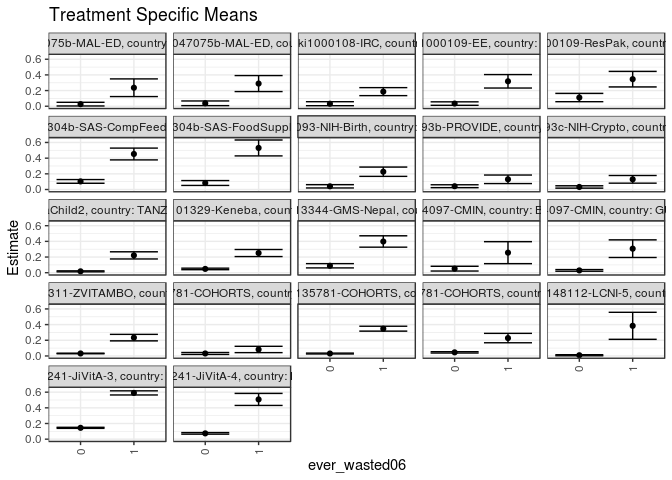

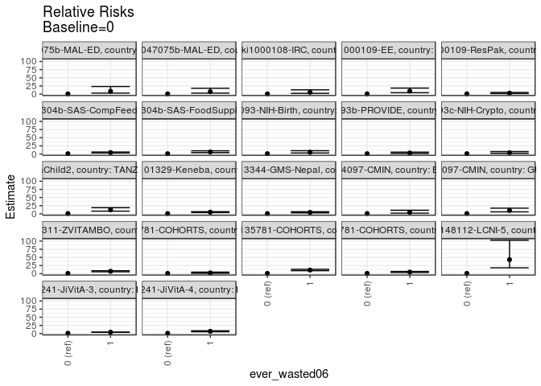

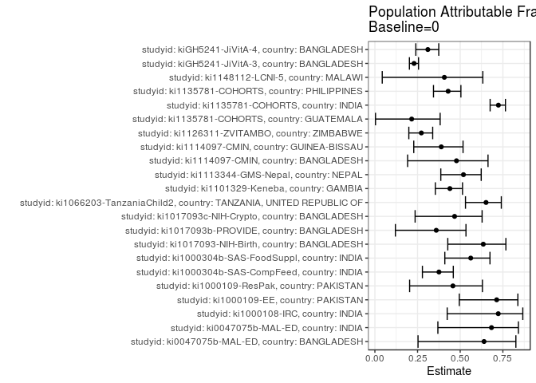

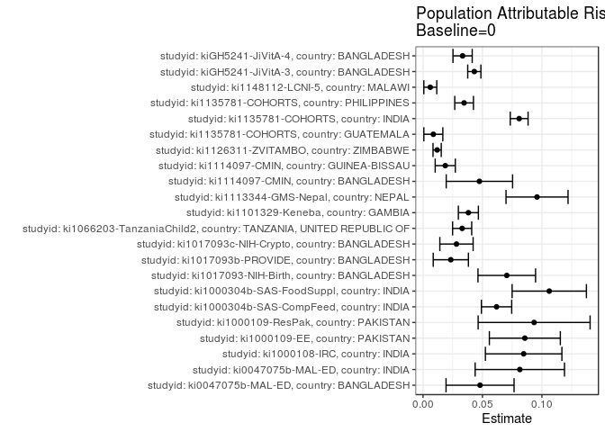

## Results Table

### Parameter: TSM

| studyid | country | intervention_level | baseline_level | estimate | ci_lower | ci_upper |
| --- | --- | --- | --- | --- | --- | --- |
| ki0047075b-MAL-ED | BANGLADESH | 0 | NA | 0.0270270 | 0.0036107 | 0.0504433 |
| ki0047075b-MAL-ED | BANGLADESH | 1 | NA | 0.2363636 | 0.1238495 | 0.3488778 |
| ki0047075b-MAL-ED | INDIA | 0 | NA | 0.0377358 | 0.0080534 | 0.0674183 |
| ki0047075b-MAL-ED | INDIA | 1 | NA | 0.2894737 | 0.1872946 | 0.3916527 |
| ki1000108-IRC | INDIA | 0 | NA | 0.0324324 | 0.0068747 | 0.0579902 |
| ki1000108-IRC | INDIA | 1 | NA | 0.1866667 | 0.1356920 | 0.2376414 |
| ki1000109-EE | PAKISTAN | 0 | NA | 0.0343511 | 0.0122682 | 0.0564341 |
| ki1000109-EE | PAKISTAN | 1 | NA | 0.3185841 | 0.2325626 | 0.4046055 |
| ki1000109-ResPak | PAKISTAN | 0 | NA | 0.1109015 | 0.0579185 | 0.1638844 |
| ki1000109-ResPak | PAKISTAN | 1 | NA | 0.3457211 | 0.2465808 | 0.4448614 |
| ki1000304b-SAS-CompFeed | INDIA | 0 | NA | 0.1028812 | 0.0792367 | 0.1265257 |
| ki1000304b-SAS-CompFeed | INDIA | 1 | NA | 0.4531347 | 0.3777765 | 0.5284929 |
| ki1000304b-SAS-FoodSuppl | INDIA | 0 | NA | 0.0828695 | 0.0518317 | 0.1139073 |
| ki1000304b-SAS-FoodSuppl | INDIA | 1 | NA | 0.5302267 | 0.4288222 | 0.6316312 |
| ki1017093-NIH-Birth | BANGLADESH | 0 | NA | 0.0404548 | 0.0193860 | 0.0615236 |
| ki1017093-NIH-Birth | BANGLADESH | 1 | NA | 0.2268047 | 0.1675423 | 0.2860672 |
| ki1017093b-PROVIDE | BANGLADESH | 0 | NA | 0.0416540 | 0.0232148 | 0.0600931 |
| ki1017093b-PROVIDE | BANGLADESH | 1 | NA | 0.1299854 | 0.0754535 | 0.1845173 |
| ki1017093c-NIH-Crypto | BANGLADESH | 0 | NA | 0.0321250 | 0.0171986 | 0.0470515 |
| ki1017093c-NIH-Crypto | BANGLADESH | 1 | NA | 0.1297183 | 0.0808373 | 0.1785993 |
| ki1066203-TanzaniaChild2 | TANZANIA, UNITED REPUBLIC OF | 0 | NA | 0.0176246 | 0.0113588 | 0.0238904 |
| ki1066203-TanzaniaChild2 | TANZANIA, UNITED REPUBLIC OF | 1 | NA | 0.2212294 | 0.1753492 | 0.2671097 |
| ki1101329-Keneba | GAMBIA | 0 | NA | 0.0486386 | 0.0390101 | 0.0582670 |
| ki1101329-Keneba | GAMBIA | 1 | NA | 0.2513537 | 0.2063339 | 0.2963735 |
| ki1113344-GMS-Nepal | NEPAL | 0 | NA | 0.0888557 | 0.0615486 | 0.1161628 |
| ki1113344-GMS-Nepal | NEPAL | 1 | NA | 0.3984959 | 0.3258812 | 0.4711105 |
| ki1114097-CMIN | BANGLADESH | 0 | NA | 0.0517759 | 0.0211921 | 0.0823596 |
| ki1114097-CMIN | BANGLADESH | 1 | NA | 0.2559545 | 0.1154761 | 0.3964329 |
| ki1114097-CMIN | GUINEA-BISSAU | 0 | NA | 0.0293795 | 0.0186729 | 0.0400861 |
| ki1114097-CMIN | GUINEA-BISSAU | 1 | NA | 0.3069140 | 0.1944388 | 0.4193892 |
| ki1126311-ZVITAMBO | ZIMBABWE | 0 | NA | 0.0317511 | 0.0281269 | 0.0353753 |
| ki1126311-ZVITAMBO | ZIMBABWE | 1 | NA | 0.2339084 | 0.1923614 | 0.2754554 |
| ki1135781-COHORTS | GUATEMALA | 0 | NA | 0.0316234 | 0.0194322 | 0.0438146 |
| ki1135781-COHORTS | GUATEMALA | 1 | NA | 0.0825970 | 0.0421128 | 0.1230812 |
| ki1135781-COHORTS | INDIA | 0 | NA | 0.0308563 | 0.0255374 | 0.0361752 |
| ki1135781-COHORTS | INDIA | 1 | NA | 0.3479154 | 0.3166361 | 0.3791947 |
| ki1135781-COHORTS | PHILIPPINES | 0 | NA | 0.0459299 | 0.0374330 | 0.0544268 |
| ki1135781-COHORTS | PHILIPPINES | 1 | NA | 0.2281154 | 0.1681447 | 0.2880862 |
| ki1148112-LCNI-5 | MALAWI | 0 | NA | 0.0089286 | 0.0022811 | 0.0155761 |
| ki1148112-LCNI-5 | MALAWI | 1 | NA | 0.3846154 | 0.2119598 | 0.5572710 |
| kiGH5241-JiVitA-3 | BANGLADESH | 0 | NA | 0.1448664 | 0.1385229 | 0.1512099 |
| kiGH5241-JiVitA-3 | BANGLADESH | 1 | NA | 0.5908040 | 0.5644969 | 0.6171111 |
| kiGH5241-JiVitA-4 | BANGLADESH | 0 | NA | 0.0739796 | 0.0640740 | 0.0838851 |
| kiGH5241-JiVitA-4 | BANGLADESH | 1 | NA | 0.5076401 | 0.4309322 | 0.5843481 |

### Parameter: E(Y)

| studyid | country | intervention_level | baseline_level | estimate | ci_lower | ci_upper |
| --- | --- | --- | --- | --- | --- | --- |
| ki0047075b-MAL-ED | BANGLADESH | NA | NA | 0.0750000 | 0.0416074 | 0.1083926 |
| ki0047075b-MAL-ED | INDIA | NA | NA | 0.1191489 | 0.0776405 | 0.1606574 |
| ki1000108-IRC | INDIA | NA | NA | 0.1170732 | 0.0859146 | 0.1482317 |
| ki1000109-EE | PAKISTAN | NA | NA | 0.1200000 | 0.0870660 | 0.1529340 |
| ki1000109-ResPak | PAKISTAN | NA | NA | 0.2043478 | 0.1521230 | 0.2565727 |
| ki1000304b-SAS-CompFeed | INDIA | NA | NA | 0.1647399 | 0.1451050 | 0.1843747 |
| ki1000304b-SAS-FoodSuppl | INDIA | NA | NA | 0.1890547 | 0.1507312 | 0.2273783 |
| ki1017093-NIH-Birth | BANGLADESH | NA | NA | 0.1109057 | 0.0844206 | 0.1373909 |
| ki1017093b-PROVIDE | BANGLADESH | NA | NA | 0.0650407 | 0.0455353 | 0.0845460 |
| ki1017093c-NIH-Crypto | BANGLADESH | NA | NA | 0.0602740 | 0.0429977 | 0.0775502 |
| ki1066203-TanzaniaChild2 | TANZANIA, UNITED REPUBLIC OF | NA | NA | 0.0505451 | 0.0409848 | 0.0601054 |
| ki1101329-Keneba | GAMBIA | NA | NA | 0.0867841 | 0.0752007 | 0.0983676 |
| ki1113344-GMS-Nepal | NEPAL | NA | NA | 0.1847458 | 0.1534039 | 0.2160876 |
| ki1114097-CMIN | BANGLADESH | NA | NA | 0.0992063 | 0.0622241 | 0.1361886 |
| ki1114097-CMIN | GUINEA-BISSAU | NA | NA | 0.0480864 | 0.0349437 | 0.0612290 |
| ki1126311-ZVITAMBO | ZIMBABWE | NA | NA | 0.0436257 | 0.0397395 | 0.0475120 |
| ki1135781-COHORTS | GUATEMALA | NA | NA | 0.0403147 | 0.0282199 | 0.0524094 |
| ki1135781-COHORTS | INDIA | NA | NA | 0.1117237 | 0.1042858 | 0.1191617 |
| ki1135781-COHORTS | PHILIPPINES | NA | NA | 0.0804843 | 0.0704205 | 0.0905481 |
| ki1148112-LCNI-5 | MALAWI | NA | NA | 0.0150565 | 0.0065967 | 0.0235162 |
| kiGH5241-JiVitA-3 | BANGLADESH | NA | NA | 0.1880070 | 0.1814627 | 0.1945512 |
| kiGH5241-JiVitA-4 | BANGLADESH | NA | NA | 0.1072724 | 0.0967392 | 0.1178055 |

### Parameter: RR

| studyid | country | intervention_level | baseline_level | estimate | ci_lower | ci_upper |
| --- | --- | --- | --- | --- | --- | --- |
| ki0047075b-MAL-ED | BANGLADESH | 0 | 0 | 1.000000 | 1.000000 | 1.000000 |
| ki0047075b-MAL-ED | BANGLADESH | 1 | 0 | 8.745454 | 3.254289 | 23.502204 |
| ki0047075b-MAL-ED | INDIA | 0 | 0 | 1.000000 | 1.000000 | 1.000000 |
| ki0047075b-MAL-ED | INDIA | 1 | 0 | 7.671053 | 3.239109 | 18.167049 |
| ki1000108-IRC | INDIA | 0 | 0 | 1.000000 | 1.000000 | 1.000000 |
| ki1000108-IRC | INDIA | 1 | 0 | 5.755556 | 2.499673 | 13.252299 |
| ki1000109-EE | PAKISTAN | 0 | 0 | 1.000000 | 1.000000 | 1.000000 |
| ki1000109-EE | PAKISTAN | 1 | 0 | 9.274336 | 4.618123 | 18.625166 |
| ki1000109-ResPak | PAKISTAN | 0 | 0 | 1.000000 | 1.000000 | 1.000000 |
| ki1000109-ResPak | PAKISTAN | 1 | 0 | 3.117372 | 1.787289 | 5.437289 |
| ki1000304b-SAS-CompFeed | INDIA | 0 | 0 | 1.000000 | 1.000000 | 1.000000 |
| ki1000304b-SAS-CompFeed | INDIA | 1 | 0 | 4.404445 | 3.174266 | 6.111377 |
| ki1000304b-SAS-FoodSuppl | INDIA | 0 | 0 | 1.000000 | 1.000000 | 1.000000 |
| ki1000304b-SAS-FoodSuppl | INDIA | 1 | 0 | 6.398331 | 4.200041 | 9.747199 |
| ki1017093-NIH-Birth | BANGLADESH | 0 | 0 | 1.000000 | 1.000000 | 1.000000 |
| ki1017093-NIH-Birth | BANGLADESH | 1 | 0 | 5.606374 | 3.128975 | 10.045279 |
| ki1017093b-PROVIDE | BANGLADESH | 0 | 0 | 1.000000 | 1.000000 | 1.000000 |
| ki1017093b-PROVIDE | BANGLADESH | 1 | 0 | 3.120602 | 1.694154 | 5.748093 |
| ki1017093c-NIH-Crypto | BANGLADESH | 0 | 0 | 1.000000 | 1.000000 | 1.000000 |
| ki1017093c-NIH-Crypto | BANGLADESH | 1 | 0 | 4.037920 | 2.219974 | 7.344587 |
| ki1066203-TanzaniaChild2 | TANZANIA, UNITED REPUBLIC OF | 0 | 0 | 1.000000 | 1.000000 | 1.000000 |
| ki1066203-TanzaniaChild2 | TANZANIA, UNITED REPUBLIC OF | 1 | 0 | 12.552318 | 8.317730 | 18.942750 |
| ki1101329-Keneba | GAMBIA | 0 | 0 | 1.000000 | 1.000000 | 1.000000 |
| ki1101329-Keneba | GAMBIA | 1 | 0 | 5.167786 | 3.962076 | 6.740410 |
| ki1113344-GMS-Nepal | NEPAL | 0 | 0 | 1.000000 | 1.000000 | 1.000000 |
| ki1113344-GMS-Nepal | NEPAL | 1 | 0 | 4.484754 | 3.139759 | 6.405911 |
| ki1114097-CMIN | BANGLADESH | 0 | 0 | 1.000000 | 1.000000 | 1.000000 |
| ki1114097-CMIN | BANGLADESH | 1 | 0 | 4.943510 | 2.210840 | 11.053851 |
| ki1114097-CMIN | GUINEA-BISSAU | 0 | 0 | 1.000000 | 1.000000 | 1.000000 |
| ki1114097-CMIN | GUINEA-BISSAU | 1 | 0 | 10.446528 | 6.234568 | 17.504012 |
| ki1126311-ZVITAMBO | ZIMBABWE | 0 | 0 | 1.000000 | 1.000000 | 1.000000 |
| ki1126311-ZVITAMBO | ZIMBABWE | 1 | 0 | 7.366940 | 5.963712 | 9.100341 |
| ki1135781-COHORTS | GUATEMALA | 0 | 0 | 1.000000 | 1.000000 | 1.000000 |
| ki1135781-COHORTS | GUATEMALA | 1 | 0 | 2.611894 | 1.401931 | 4.866138 |
| ki1135781-COHORTS | INDIA | 0 | 0 | 1.000000 | 1.000000 | 1.000000 |
| ki1135781-COHORTS | INDIA | 1 | 0 | 11.275339 | 9.284691 | 13.692785 |
| ki1135781-COHORTS | PHILIPPINES | 0 | 0 | 1.000000 | 1.000000 | 1.000000 |
| ki1135781-COHORTS | PHILIPPINES | 1 | 0 | 4.966599 | 3.606049 | 6.840480 |
| ki1148112-LCNI-5 | MALAWI | 0 | 0 | 1.000000 | 1.000000 | 1.000000 |
| ki1148112-LCNI-5 | MALAWI | 1 | 0 | 43.076923 | 18.058272 | 102.757410 |
| kiGH5241-JiVitA-3 | BANGLADESH | 0 | 0 | 1.000000 | 1.000000 | 1.000000 |
| kiGH5241-JiVitA-3 | BANGLADESH | 1 | 0 | 4.078268 | 3.836932 | 4.334784 |
| kiGH5241-JiVitA-4 | BANGLADESH | 0 | 0 | 1.000000 | 1.000000 | 1.000000 |
| kiGH5241-JiVitA-4 | BANGLADESH | 1 | 0 | 6.861896 | 5.596597 | 8.413258 |

### Parameter: PAR

| studyid | country | intervention_level | baseline_level | estimate | ci_lower | ci_upper |
| --- | --- | --- | --- | --- | --- | --- |
| ki0047075b-MAL-ED | BANGLADESH | 0 | NA | 0.0479730 | 0.0193712 | 0.0765747 |
| ki0047075b-MAL-ED | INDIA | 0 | NA | 0.0814131 | 0.0438395 | 0.1189866 |
| ki1000108-IRC | INDIA | 0 | NA | 0.0846407 | 0.0524758 | 0.1168057 |
| ki1000109-EE | PAKISTAN | 0 | NA | 0.0856489 | 0.0558012 | 0.1154965 |
| ki1000109-ResPak | PAKISTAN | 0 | NA | 0.0934464 | 0.0463585 | 0.1405342 |
| ki1000304b-SAS-CompFeed | INDIA | 0 | NA | 0.0618587 | 0.0491210 | 0.0745964 |
| ki1000304b-SAS-FoodSuppl | INDIA | 0 | NA | 0.1061852 | 0.0749383 | 0.1374321 |
| ki1017093-NIH-Birth | BANGLADESH | 0 | NA | 0.0704509 | 0.0462323 | 0.0946695 |
| ki1017093b-PROVIDE | BANGLADESH | 0 | NA | 0.0233867 | 0.0085869 | 0.0381865 |
| ki1017093c-NIH-Crypto | BANGLADESH | 0 | NA | 0.0281489 | 0.0141549 | 0.0421429 |
| ki1066203-TanzaniaChild2 | TANZANIA, UNITED REPUBLIC OF | 0 | NA | 0.0329205 | 0.0248850 | 0.0409561 |
| ki1101329-Keneba | GAMBIA | 0 | NA | 0.0381456 | 0.0297268 | 0.0465643 |
| ki1113344-GMS-Nepal | NEPAL | 0 | NA | 0.0958901 | 0.0698031 | 0.1219771 |
| ki1114097-CMIN | BANGLADESH | 0 | NA | 0.0474305 | 0.0195156 | 0.0753454 |
| ki1114097-CMIN | GUINEA-BISSAU | 0 | NA | 0.0187068 | 0.0102377 | 0.0271760 |
| ki1126311-ZVITAMBO | ZIMBABWE | 0 | NA | 0.0118746 | 0.0084175 | 0.0153318 |
| ki1135781-COHORTS | GUATEMALA | 0 | NA | 0.0086912 | 0.0007107 | 0.0166718 |
| ki1135781-COHORTS | INDIA | 0 | NA | 0.0808674 | 0.0733675 | 0.0883674 |
| ki1135781-COHORTS | PHILIPPINES | 0 | NA | 0.0345544 | 0.0266846 | 0.0424242 |
| ki1148112-LCNI-5 | MALAWI | 0 | NA | 0.0061279 | 0.0006884 | 0.0115674 |
| kiGH5241-JiVitA-3 | BANGLADESH | 0 | NA | 0.0431406 | 0.0376064 | 0.0486748 |
| kiGH5241-JiVitA-4 | BANGLADESH | 0 | NA | 0.0332928 | 0.0252073 | 0.0413783 |

### Parameter: PAF

| studyid | country | intervention_level | baseline_level | estimate | ci_lower | ci_upper |
| --- | --- | --- | --- | --- | --- | --- |
| ki0047075b-MAL-ED | BANGLADESH | 0 | NA | 0.6396396 | 0.2527566 | 0.8262151 |
| ki0047075b-MAL-ED | INDIA | 0 | NA | 0.6832884 | 0.3691087 | 0.8410087 |
| ki1000108-IRC | INDIA | 0 | NA | 0.7229730 | 0.4236989 | 0.8668336 |
| ki1000109-EE | PAKISTAN | 0 | NA | 0.7137405 | 0.4945346 | 0.8378830 |
| ki1000109-ResPak | PAKISTAN | 0 | NA | 0.4572907 | 0.2035132 | 0.6302094 |
| ki1000304b-SAS-CompFeed | INDIA | 0 | NA | 0.3754929 | 0.2784446 | 0.4594883 |
| ki1000304b-SAS-FoodSuppl | INDIA | 0 | NA | 0.5616638 | 0.4098343 | 0.6744327 |
| ki1017093-NIH-Birth | BANGLADESH | 0 | NA | 0.6352325 | 0.4271624 | 0.7677260 |
| ki1017093b-PROVIDE | BANGLADESH | 0 | NA | 0.3595703 | 0.1202358 | 0.5337953 |
| ki1017093c-NIH-Crypto | BANGLADESH | 0 | NA | 0.4670163 | 0.2356647 | 0.6283416 |
| ki1066203-TanzaniaChild2 | TANZANIA, UNITED REPUBLIC OF | 0 | NA | 0.6513096 | 0.5309093 | 0.7408071 |
| ki1101329-Keneba | GAMBIA | 0 | NA | 0.4395455 | 0.3543073 | 0.5135314 |
| ki1113344-GMS-Nepal | NEPAL | 0 | NA | 0.5190380 | 0.3862756 | 0.6230810 |
| ki1114097-CMIN | BANGLADESH | 0 | NA | 0.4780993 | 0.1918344 | 0.6629648 |
| ki1114097-CMIN | GUINEA-BISSAU | 0 | NA | 0.3890259 | 0.2277563 | 0.5166172 |
| ki1126311-ZVITAMBO | ZIMBABWE | 0 | NA | 0.2721936 | 0.1988978 | 0.3387833 |
| ki1135781-COHORTS | GUATEMALA | 0 | NA | 0.2155852 | 0.0035196 | 0.3825201 |
| ki1135781-COHORTS | INDIA | 0 | NA | 0.7238160 | 0.6752824 | 0.7650955 |
| ki1135781-COHORTS | PHILIPPINES | 0 | NA | 0.4293311 | 0.3433759 | 0.5040344 |
| ki1148112-LCNI-5 | MALAWI | 0 | NA | 0.4069940 | 0.0430324 | 0.6325309 |
| kiGH5241-JiVitA-3 | BANGLADESH | 0 | NA | 0.2294626 | 0.2022603 | 0.2557373 |
| kiGH5241-JiVitA-4 | BANGLADESH | 0 | NA | 0.3103577 | 0.2398989 | 0.3742852 |